# Analysis_TDS_122020

REPORT: TOWARDS DATA SCIENCE PUBLICATION IN DEC 2020

[figure not shown]

Web scraping & data analysis by Thuong Nguyen

LOAD AND PROCESS DATA

```python
import pandas as pd
import seaborn as sns
import plotly.express as px
import datetime as dt
import holidays
```

```python
data=pd.read_csv('dataTDS_122020.csv',parse_dates=['Date'])
```

```python
data.head()
```

|  | Date | Author | Title | Read time | No of Clap |
| --- | --- | --- | --- | --- | --- |
| 0 | 2020-12-01 | Martin Heinz | Networking Tools Every Developer Needs to Know | 9 | 291 |
| 1 | 2020-12-01 | Dario Radečić | Ridgeline Plots: The Perfect Way to Visualize ... | 4 | 397 |
| 2 | 2020-12-01 | Davis David | How to deploy Machine Learning Model in Larave... | 6 | 153 |
| 3 | 2020-12-01 | Anna Anisienia | 15 Essential Steps To Build Reliable Data Pipe... | 11 | 433 |
| 4 | 2020-12-01 | Daniel Morales | Creating the Whole Machine Learning Pipeline w... | 20 | 115 |

```python
data.tail()
```

|  | Date | Author | Title | Read time | No of Clap |
| --- | --- | --- | --- | --- | --- |
| 1561 | 2020-12-31 | Kavinda Jayawardana | Concatenating Multiple Activation Functions an... | 9 | 13 |
| 1562 | 2020-12-31 | Prerak Mody | Custom Training Loops for Medical Image Segmen... | 4 | 22 |
| 1563 | 2020-12-31 | Victor Morgante | External Uniqueness Constraints — Object-Role ... | 4 | 1 |
| 1564 | 2020-12-31 | Namrata Kapoor | Understanding Transformers | 8 | 917 |
| 1565 | 2020-12-31 | Manu Cohen-Yashar | Data Governance & Azure Purview Evaluation | 8 | 3 |

```python
data.info()
```

```
<class 'pandas.core.frame.DataFrame'>
RangeIndex: 1566 entries, 0 to 1565
Data columns (total 5 columns):
 #   Column      Non-Null Count  Dtype
---  ------      --------------  -----
 0   Date        1566 non-null   datetime64[ns]
 1   Author      1566 non-null   object
 2   Title       1562 non-null   object
 3   Read time   1566 non-null   int64
 4   No of Clap  1547 non-null   object
dtypes: datetime64[ns](1), int64(1), object(3)
memory usage: 61.3+ KB
```

```python
data['No of Clap']=data['No of Clap'].str.replace('K','000')
```

```python
data['No of Clap']=data['No of Clap'].str.replace('.','')
```

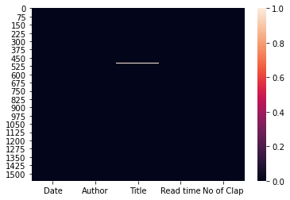

```python
sns.heatmap(data.isna())
```

```python
data.fillna(0,inplace=True)
```

```python
data['No of Clap']=data['No of Clap'].astype('int64')
```

```python
data.info()
```

```
<class 'pandas.core.frame.DataFrame'>
RangeIndex: 1566 entries, 0 to 1565
Data columns (total 5 columns):
 #   Column      Non-Null Count  Dtype
---  ------      --------------  -----
 0   Date        1566 non-null   datetime64[ns]
 1   Author      1566 non-null   object
 2   Title       1566 non-null   object
 3   Read time   1566 non-null   int64
 4   No of Clap  1566 non-null   int64
dtypes: datetime64[ns](1), int64(2), object(2)
memory usage: 61.3+ KB
```

ANALYSIS

# Number of published articles by working days, weekends, holidays & recommendation for writers

```python
data1=data[['Date','Title']].set_index(keys=['Date'])
```

```python
data_1=data1.resample('D').count()
```

```python
category=[]
for i in data_1.index:
    if i.strftime('%a')in ['Sat','Sun']:
            if i in holidays.CA():
                category.append('holiday')
            else:
                category.append('weekend')
    else:
            if i in holidays.CA():
                category.append('holiday')
            else:
                category.append('workday')
```

```python
len(category)
```

```
31
```

```python
data_1['day']=category
```

```python
fig=px.bar(data_1,color='day')
fig.update_xaxes(title='Date')
fig.update_yaxes(title='Count number of articles published')

fig.add_hline(y=data_1.Title.mean(),line_color='red')

fig.show()

#ve them hline bieu dien average value cua count
```

[interactive chart not shown]

Majority of low published days belong to weekend and holiday. Recommendation: avoid weekend and holiday to publish your stories. The 2nd and 3rd week of the month are good options.

# Which days of the week have high number of publised articles?

```python
fig=px.bar(data[['Date','Title']].groupby(data['Date'].dt.strftime('%a'))['Title'].count(),color='value')
fig.update_yaxes(title='Count number of article published')
fig.show()
```

[interactive chart not shown]

Basing on high count of publised articles, becommendations are suggested in priority order:

Tue first

Wed

Mon or Thu

# Frequency of read time

```python
px.histogram(data,x='Read time')
```

[interactive chart not shown]

Majoriry of article publised on TDS have read time 3 to 12 minutes (the most requently appeared articles on TDS are 6 mins reading) but too short (<3mins) or too long(>12mins) are rare. Some exceptional articles >36 minutes exist.

# Top 10 Authors

```python
px.bar(data.Author.value_counts()[:10])
```

[interactive chart not shown]

Top Author (articles count): Soner Yildirim, then TSD Editors

# Testing title contains keywords

```python
h=data.Title.str.contains('[Hh]ow to',na=False).sum()*100/1566
```

```python
p=data.Title.str.contains('[Pp]ython',na=False).sum()*100/1566
```

```python
d=data.Title.str.contains('[Dd]ata',na=False).sum()*100/1566
```

```python
a=data.Title.str.contains('AI',na=False).sum()*100/1566
```

```python
m=data.Title.str.contains('[Mm]achine [Ll]earning',na=False).sum()*100/1566
```

```python
fig=px.bar(y=[h,p,d,a,m],x=['How to','Python','Data','AI','Machine Learning'])
fig.update_yaxes(title='Percentage')
fig.update_xaxes(title='Titles contain')
fig.show()
```

[interactive chart not shown]

# High claps vs read time

```python
fig=px.scatter(data,x='Read time',y='No of Clap')
fig.add_vline(x=4,line_color='red')
fig.add_vline(x=12,line_color='red')
fig.add_hline(y=0,line_color='black')
fig.add_hline(y=1000,line_color='black')
fig.show()
```

[interactive chart not shown]

Normal articles receives from 0 to within 1000 claps, the high claps belongs to several articles which have read time 4 to 12 minutes.